# P9_Ensemble methods_Kyuri

Kyuri Park

October 15, 2022

# Introduction

First, load the packages:

```r
library(tidyverse)
library(magrittr)
library(caret)
library(gbm)
library(xgboost)
library(data.table)
library(ggforce)
```

First, we specify a seed and load the training data. We will use this data to make inferences and to train a prediction model.

```r
set.seed(123)
df <- readRDS("data/train_disease.RDS")
```

## 1. Get an impression of the data by looking at the structure of the data and creating some descriptive statistics.

```r
str(df)
```

```
tibble [500 × 11] (S3: tbl_df/tbl/data.frame)
 $ Age                       : num [1:500] 58 56 35 51 21 60 48 48 67 36 ...
 $ Gender                    : Factor w/ 2 levels "Male","Female": 2 1 1 2 1 1 2 2 1 2 ...
 $ Total_Bilirubin           : num [1:500] 1.7 1 2 0.9 18.5 3.2 1.1 1 2.2 0.7 ...
 $ Direct_Bilirubin          : num [1:500] 0.8 0.3 1.1 0.2 9.5 1.8 0.7 1.4 1.1 0.2 ...
 $ Alkaline_Phosphotase      : num [1:500] 1896 195 226 280 380 ...
 $ Alamine_Aminotransferase  : num [1:500] 61 22 33 21 390 79 178 18 42 21 ...
 $ Aspartate_Aminotransferase: num [1:500] 83 28 135 30 500 145 250 14 39 25 ...
 $ Total_Protiens            : num [1:500] 8 5.8 6 6.7 8.2 7.8 8 8.3 7.2 5.9 ...
 $ Albumin                   : num [1:500] 3.9 2.6 2.7 3.2 4.1 3.2 4.2 4.2 3 3.1 ...
 $ Ratio_Albumin_Globulin    : num [1:500] 0.95 0.8 0.8 0.8 1 0.69 1.1 1 0.7 1.1 ...
 $ Disease                   : Factor w/ 2 levels "Healthy","Disease": 1 2 2 1 1 1 1 1 1 2 ...
 - attr(*, "na.action")= 'omit' Named int [1:4] 210 242 254 313
  ..- attr(*, "names")= chr [1:4] "210" "242" "254" "313"
```

```r
# use skim
skimr::skim(df)
```

Data summary

| Name | df |
| --- | --- |
| Number of rows | 500 |
| Number of columns | 11 |
| _______________________ |  |
| Column type frequency: |  |
| factor | 2 |
| numeric | 9 |
| ________________________ |  |
| Group variables | None |

**Variable type: factor**

| skim_variable | n_missing | complete_rate | ordered | n_unique | top_counts |
| --- | --- | --- | --- | --- | --- |
| Gender | 0 | 1 | FALSE | 2 | Mal: 377, Fem: 123 |
| Disease | 0 | 1 | FALSE | 2 | Hea: 360, Dis: 140 |

**Variable type: numeric**

| skim_variable | n_missing | complete_rate | mean | sd | p0 | p25 | p50 | p75 | p100 | hist |
| --- | --- | --- | --- | --- | --- | --- | --- | --- | --- | --- |
| Age | 0 | 1 | 44.60 | 16.10 | 4.0 | 33.0 | 45.00 | 57.00 | 90.0 | ▂▇▇▅▁ |
| Total_Bilirubin | 0 | 1 | 3.24 | 6.23 | 0.4 | 0.8 | 1.00 | 2.52 | 75.0 | ▇▁▁▁▁ |
| Direct_Bilirubin | 0 | 1 | 1.45 | 2.77 | 0.1 | 0.2 | 0.30 | 1.20 | 19.7 | ▇▁▁▁▁ |
| Alkaline_Phosphotase | 0 | 1 | 284.58 | 230.09 | 63.0 | 175.0 | 208.00 | 292.25 | 2110.0 | ▇▁▁▁▁ |
| Alamine_Aminotransferase | 0 | 1 | 79.30 | 172.68 | 10.0 | 22.0 | 35.00 | 61.25 | 1680.0 | ▇▁▁▁▁ |
| Aspartate_Aminotransferase | 0 | 1 | 107.38 | 279.13 | 10.0 | 25.0 | 41.00 | 86.25 | 4929.0 | ▇▁▁▁▁ |
| Total_Protiens | 0 | 1 | 6.49 | 1.10 | 2.7 | 5.8 | 6.60 | 7.20 | 9.6 | ▁▃▇▇▁ |
| Albumin | 0 | 1 | 3.15 | 0.81 | 0.9 | 2.6 | 3.10 | 3.80 | 5.5 | ▁▆▇▆▁ |
| Ratio_Albumin_Globulin | 0 | 1 | 0.95 | 0.32 | 0.3 | 0.7 | 0.95 | 1.10 | 2.8 | ▆▇▂▁▁ |

```r
# use describeBy
df %>% select(-c(Disease, Gender)) %>%
psych::describeBy(df$Disease, fast=T)
```

```
 Descriptive statistics by group
group: Healthy
                           vars   n   mean     sd  min    max  range    se
Age                           1 360  45.81  15.60 10.0   90.0   80.0  0.82
Total_Bilirubin               2 360   4.05   7.15  0.4   75.0   74.6  0.38
Direct_Bilirubin              3 360   1.86   3.16  0.1   19.7   19.6  0.17
Alkaline_Phosphotase          4 360 309.47 250.37 63.0 2110.0 2047.0 13.20
Alamine_Aminotransferase      5 360  97.19 200.17 12.0 1680.0 1668.0 10.55
Aspartate_Aminotransferase    6 360 133.66 324.59 11.0 4929.0 4918.0 17.11
Total_Protiens                7 360   6.47   1.11  2.7    9.6    6.9  0.06
Albumin                       8 360   3.07   0.80  0.9    5.5    4.6  0.04
Ratio_Albumin_Globulin        9 360   0.92   0.32  0.3    2.8    2.5  0.02
------------------------------------------------------------
group: Disease
                           vars   n   mean     sd   min    max   range    se
Age                           1 140  41.51  16.98  4.00   85.0   81.00  1.43
Total_Bilirubin               2 140   1.14   1.01  0.50    7.3    6.80  0.09
Direct_Bilirubin              3 140   0.40   0.53  0.10    3.6    3.50  0.04
Alkaline_Phosphotase          4 140 220.56 149.76 90.00 1580.0 1490.00 12.66
Alamine_Aminotransferase      5 140  33.31  24.50 10.00  181.0  171.00  2.07
Aspartate_Aminotransferase    6 140  39.79  34.79 10.00  285.0  275.00  2.94
Total_Protiens                7 140   6.53   1.07  3.70    9.2    5.50  0.09
Albumin                       8 140   3.34   0.80  1.40    5.0    3.60  0.07
Ratio_Albumin_Globulin        9 140   1.04   0.30  0.37    1.9    1.53  0.03
```

## 2. To further explore the data we work with, create some interesting data visualizations that show whether there are interesting patterns in the data.

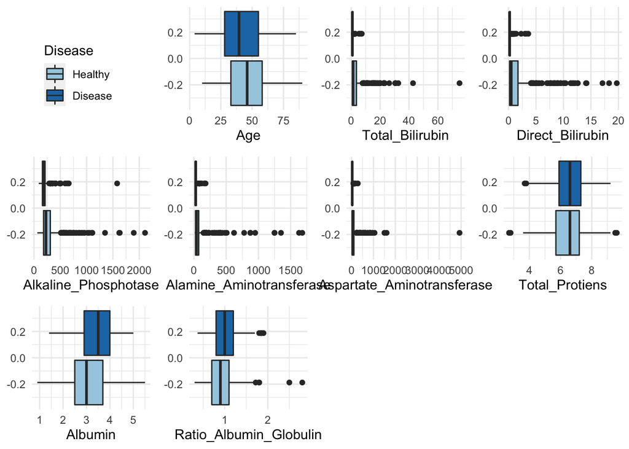

```r
# to extract legend
p1 <- ggplot(df, aes(x = Age, fill = Disease)) + geom_boxplot() +        scale_fill_brewer(palette = "Paired") + theme(legend.direction = "vertical")
legend <- cowplot::get_legend(p1)

# create multiple boxplots
plots <- df %>%
  select(-c(Disease, Gender)) %>%
  names() %>%
  map(~ggplot(df, aes_string(x = ., fill = "Disease")) +
        geom_boxplot() +
        scale_fill_brewer(palette = "Paired") +
        theme_minimal() + theme(legend.position = "none"))

cowplot::plot_grid(plotlist = plots ,legend)
```

## 3. Shortly reflect on the difference between bagging, random forests, and boosting.

- Bagging: Fit a regression tree to N bootstrap samples of the training data, and take the average of all classification trees to base predictions on.  
  *Note*: out-of-bag data can serve as internal validation set.
- Random forest: Similarly to bagging, classification trees are trained on a bootstrap sample of the data. However, the decision trees are trained using less than all features in the data.
- Boosting: We build a decision tree sequentially. Given the current, we fit a (small) tree on the residuals of the current model, rather than on the outcome Y.

# Bagging

## 4. Apply bagging to the training data, to predict the outcome `Disease`, using the `caret` library.

*Note.* We first specify the internal validation settings, like so:

```r
cvcontrol <- trainControl(method = "repeatedcv",
                          number = 10,
                          allowParallel = TRUE)
```

```r
bag_train <- train(Disease ~ .,
                   data = df,
                   method = 'treebag',
                   trControl = cvcontrol,
                   importance = TRUE)
```

## 5. Interpret the variable importance measure using the `varImp` function on the trained model object.

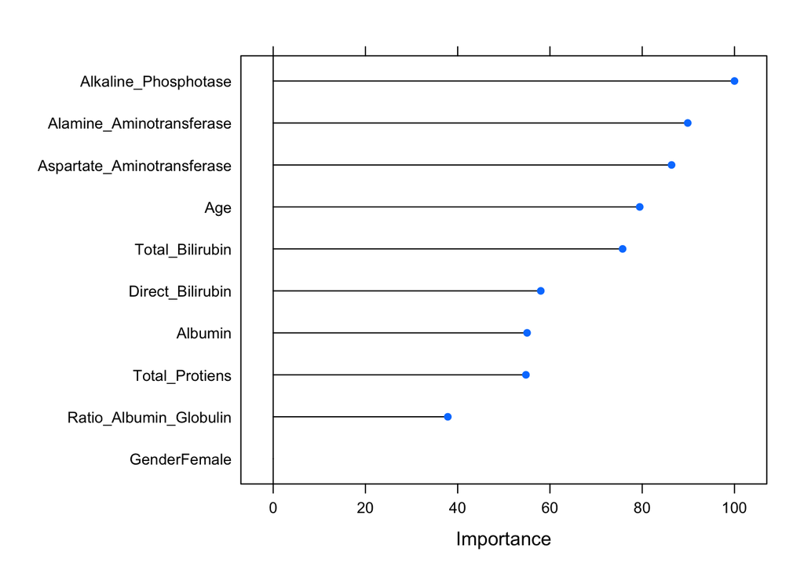

```r
varImp(bag_train) %>% plot
```

## 6. Create training set predictions based on the bagged model, and use the `confusionMatrix()` function from the `caret` package to assess it’s performance.

```r
preds <- predict(bag_train)
confusionMatrix(preds, df$Disease)
```

```
Confusion Matrix and Statistics

          Reference
Prediction Healthy Disease
   Healthy     360       0
   Disease       0     140

               Accuracy : 1
                 95% CI : (0.9926, 1)
    No Information Rate : 0.72
    P-Value [Acc > NIR] : < 2.2e-16

                  Kappa : 1

 Mcnemar's Test P-Value : NA

            Sensitivity : 1.00
            Specificity : 1.00
         Pos Pred Value : 1.00
         Neg Pred Value : 1.00
             Prevalence : 0.72
         Detection Rate : 0.72
   Detection Prevalence : 0.72
      Balanced Accuracy : 1.00

       'Positive' Class : Healthy
```

## 7. Now ask for the output of the bagged model. Explain why the under both approaches differ.

```r
bag_train
```

```
Bagged CART

500 samples
 10 predictor
  2 classes: 'Healthy', 'Disease'

No pre-processing
Resampling: Cross-Validated (10 fold, repeated 1 times)
Summary of sample sizes: 450, 450, 450, 450, 450, 450, ...
Resampling results:

  Accuracy  Kappa
  0.682     0.122688
```

# Random Forest

## 8. Fit a random forest to the training data to predict the outcome `Disease`, using the `caret` library.

```r
rf_train <- train(Disease ~ .,
                  data = df,
                  method = 'rf',
                  trControl = cvcontrol,
                  importance = TRUE)
```

## 9. Again, interpret the variable importance measure using the `varImp` function on the trained model object. Do you draw the same conclusions as under the bagged model?

No, slightly different.

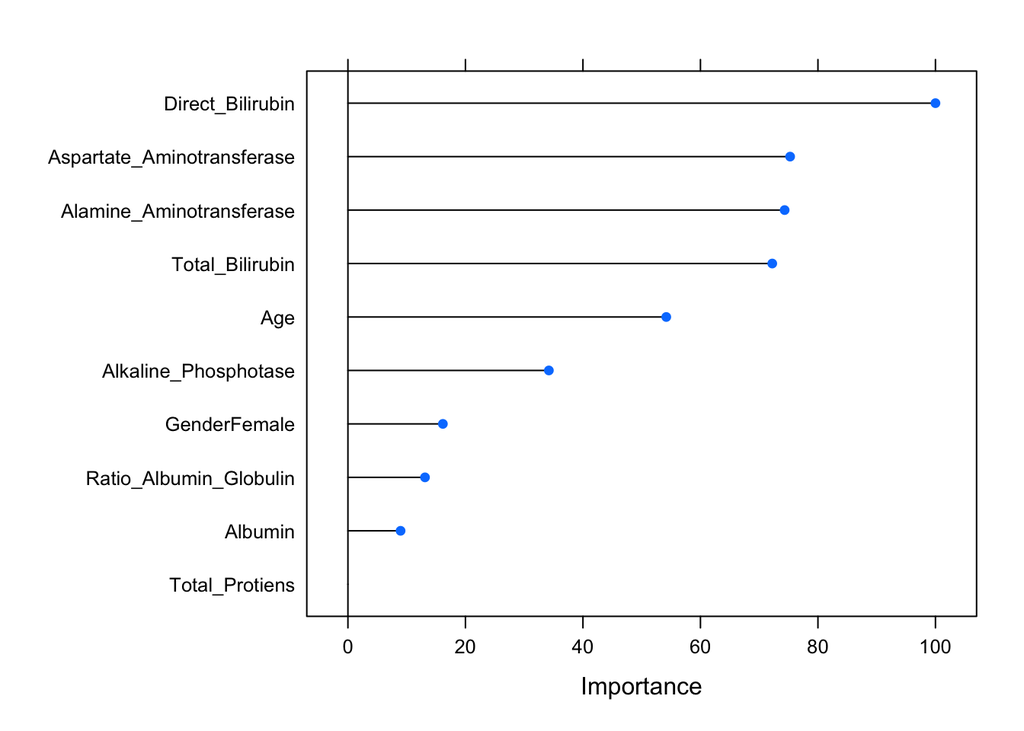

```r
varImp(rf_train) %>%  plot
```

## 10. Output the model output from the random forest. Are we doing better than with the bagged model?

```r
rf_train
```

```
Random Forest

500 samples
 10 predictor
  2 classes: 'Healthy', 'Disease'

No pre-processing
Resampling: Cross-Validated (10 fold, repeated 1 times)
Summary of sample sizes: 450, 450, 450, 450, 450, 450, ...
Resampling results across tuning parameters:

  mtry  Accuracy  Kappa
   2    0.702     0.1386273
   6    0.698     0.1600461
  10    0.684     0.1283499

Accuracy was used to select the optimal model using the largest value.
The final value used for the model was mtry = 2.
```

# Boosting

## 11. Now, fit a boosting model using the `caret` library to predict disease status.

```r
gbm_train <- train(Disease ~ .,
                   data = df,
                   method = "gbm",
                   verbose = F,
                   trControl = cvcontrol)
```

## 12. Again, interpret the variable importance measure. You will have to call for `summary()` on the model object you just created. Compare the output to the previously obtained variable importance measures.

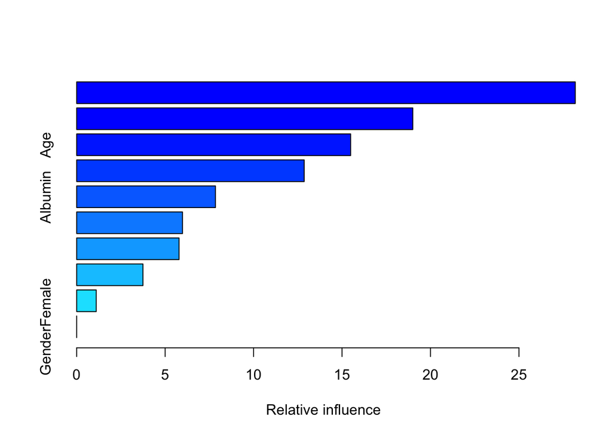

|  | var | rel.inf |
| --- | --- | --- |
| Aspartate_Aminotransferase | Aspartate_Aminotransferase | 28.184163 |
| Alkaline_Phosphotase | Alkaline_Phosphotase | 18.999430 |
| Age | Age | 15.487442 |
| Total_Bilirubin | Total_Bilirubin | 12.860984 |
| Albumin | Albumin | 7.845740 |
| Direct_Bilirubin | Direct_Bilirubin | 5.981951 |
| Alamine_Aminotransferase | Alamine_Aminotransferase | 5.787702 |
| Total_Protiens | Total_Protiens | 3.746809 |
| Ratio_Albumin_Globulin | Ratio_Albumin_Globulin | 1.105780 |
| GenderFemale | GenderFemale | 0.000000 |

```r
summary(gbm_train)
```

## 13. Output the model output from our gradient boosting procedure. Are we doing better than with the bagged and random forest model?

```r
gbm_train
```

```
Stochastic Gradient Boosting

500 samples
 10 predictor
  2 classes: 'Healthy', 'Disease'

No pre-processing
Resampling: Cross-Validated (10 fold, repeated 1 times)
Summary of sample sizes: 450, 450, 450, 450, 450, 450, ...
Resampling results across tuning parameters:

  interaction.depth  n.trees  Accuracy  Kappa
  1                   50      0.712     0.1225564
  1                  100      0.696     0.1219263
  1                  150      0.696     0.1404609
  2                   50      0.704     0.1438056
  2                  100      0.698     0.1656265
  2                  150      0.694     0.1651909
  3                   50      0.702     0.1531388
  3                  100      0.688     0.1535726
  3                  150      0.672     0.1208735

Tuning parameter 'shrinkage' was held constant at a value of 0.1

Tuning parameter 'n.minobsinnode' was held constant at a value of 10
Accuracy was used to select the optimal model using the largest value.
The final values used for the model were n.trees = 50, interaction.depth =
 1, shrinkage = 0.1 and n.minobsinnode = 10.
```

## 14. Download the file `shap.R` from [this](https://github.com/pablo14/shap-values) Github repository.

*Note.* There are multiple ways to this, of which the simplest is to run the following code.

```r
library(devtools)
source_url("https://github.com/pablo14/shap-values/blob/master/shap.R?raw=TRUE")
```

## 15. Specify your model as follows, and use it to create predictions on the training data.

```r
train_x <- model.matrix(Disease ~ ., df)[,-1]
train_y <- as.numeric(df$Disease) - 1
xgboost_train <- xgboost(data = train_x,
                         label = train_y,
                         max.depth = 10,
                         eta = 1,
                         nthread = 4,
                         nrounds = 4,
                         objective = "binary:logistic",
                         verbose = 2)
pred <- tibble(Disease = predict(xgboost_train, newdata = train_x)) %>%
  mutate(Disease = factor(ifelse(Disease < 0.5, 1, 2),
                          labels = c("Healthy", "Disease")))

table(pred$Disease, df$Disease)
```

```
          Healthy Disease
  Healthy     357       6
  Disease       3     134
```

## 16. First, calculate the `SHAP` rank scores for all variables in the data, and create a variable importance plot using these values. Interpret the plot.

```r
shap_results <- shap.score.rank(xgboost_train,
                                X_train = train_x,
                                shap_approx = F)
```

```
make SHAP score by decreasing order
```

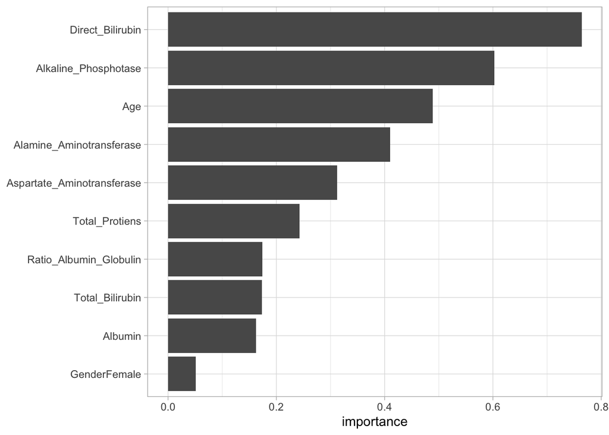

```r
var_importance(shap_results)
```

## 17. Plot the `SHAP` values for every individual for every feature and interpret them.

The first plot shows, for example, that those with a high value for `Direct_Bilirubin` have a lower probability of being diseased. Also, those with a higher `age` have a lower probability of being diseased, while those with a higher `Albumin` have a higher probability of being diseased.

The second set of plots displays the marginal relationships of the SHAP values with the predictors. This conveys the same information, but in greater detail. The interpretability may be a bit tricky for the inexperienced data analyst.

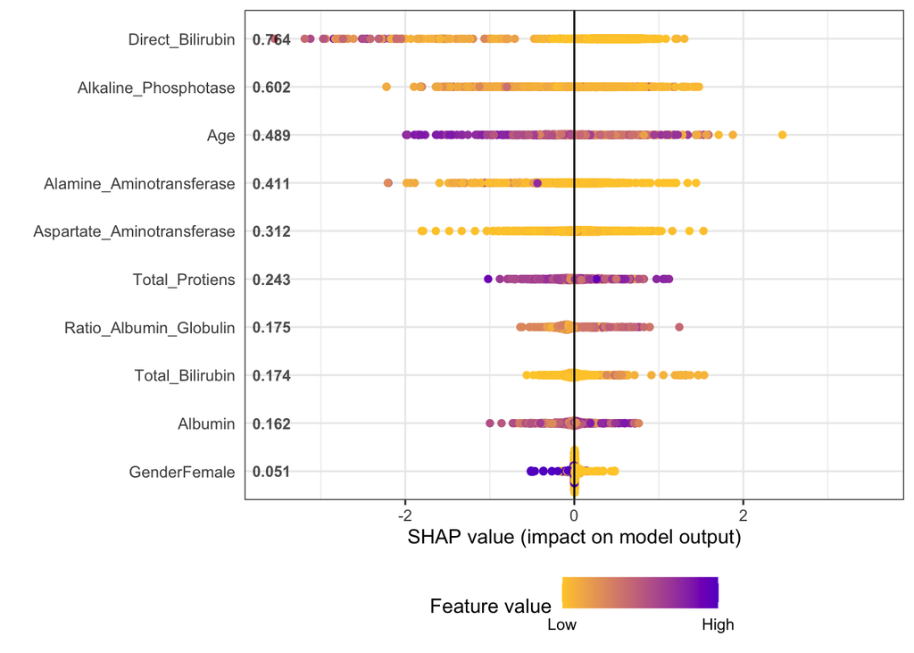

```r
shap_long <- shap.prep(shap = shap_results,
                       X_train = train_x)

plot.shap.summary(shap_long)
```

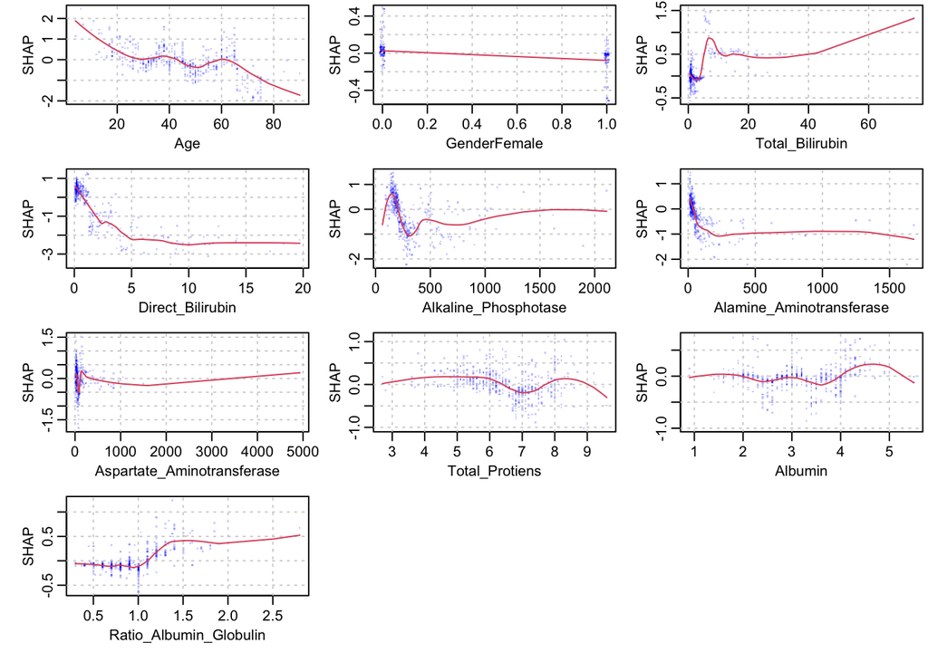

```r
xgb.plot.shap(train_x, features = colnames(train_x), model = xgboost_train, n_col = 3)
```

# Evaluation

## 18. Verify which of the models you created in this practical performs best on the test data.

There isn’t dramatic difference across the models. But random forest and boosting seem to relatively work better than the other two models.

```r
# load test dataset
test <- readRDS("data/test_disease.RDS")

bag_test <- predict(bag_train, newdata = test)
rf_test  <- predict(rf_train, newdata = test)
gbm_test <- predict(gbm_train, newdata = test)
xgb_test <- predict(xgboost_train, newdata = model.matrix(Disease ~ ., test)[,-1]) %>%
  factor(x = ifelse(. < 0.5, 1, 2), levels = c(1,2), labels = c("Healthy", "Disease"))

list(bag_test,
     rf_test,
     gbm_test,
     xgb_test) %>%
  map(~ confusionMatrix(.x, test$Disease))
```

```
[[1]]
Confusion Matrix and Statistics

          Reference
Prediction Healthy Disease
   Healthy      46      18
   Disease       8       7

               Accuracy : 0.6709
                 95% CI : (0.556, 0.7725)
    No Information Rate : 0.6835
    P-Value [Acc > NIR] : 0.64632

                  Kappa : 0.1477

 Mcnemar's Test P-Value : 0.07756

            Sensitivity : 0.8519
            Specificity : 0.2800
         Pos Pred Value : 0.7188
         Neg Pred Value : 0.4667
             Prevalence : 0.6835
         Detection Rate : 0.5823
   Detection Prevalence : 0.8101
      Balanced Accuracy : 0.5659

       'Positive' Class : Healthy


[[2]]
Confusion Matrix and Statistics

          Reference
Prediction Healthy Disease
   Healthy      52      18
   Disease       2       7

               Accuracy : 0.7468
                 95% CI : (0.6364, 0.838)
    No Information Rate : 0.6835
```

[output cut: 59 more lines]

```

                  Kappa : 0.2663

 Mcnemar's Test P-Value : 0.5403

            Sensitivity : 0.8148
            Specificity : 0.4400
         Pos Pred Value : 0.7586
         Neg Pred Value : 0.5238
             Prevalence : 0.6835
         Detection Rate : 0.5570
   Detection Prevalence : 0.7342
      Balanced Accuracy : 0.6274

       'Positive' Class : Healthy
```